**← Back to Project Index**

# **APOE & PTAU217 Project**

**Author:** Juan E. Garcia  
**Project Owner & Requester:** Amaya M. Seidl  
**Final Version:** *November 14, 2025*

### **Purpose**

- The purpose of this notebook is to merge **APOE** and **pTau217** data on available records to explore genetic and biomarker associations across diagnostic and demographic groups.
- As well identifying population-specific risk factors and metrics related to **AD among Hispanics**.

### **Aim 1: APOE ε4 Prevalence and Impact**

**Objectives**

1. **Assess ε4 prevalence and impact** as a risk factor among **Hispanics** vs. **non-Hispanic Whites (NHWs)**.
2. **Compare ε4 carriership** between Hispanics and NHWs across **three diagnostic groups**:
   - Normal Cognition
   - Mild Cognitive Impairment (MCI)
   - Dementia
3. **Assess ε4** as a risk factor for cognitive diagnosis (Normal Cognition = control) while accounting for **cardiovascular comorbidities**.
4. **Evaluate interaction effects** — determine if APOE ε4 associations differ significantly by ethnicity.
   - Adjust analyses for **age**, **sex**, and **education**.
   - Reference tables and figures will illustrate stratified comparisons.

### **Aim 2: pTau217 Distributions Across Diagnostic and Ethnic Groups**

**Objectives**

1. Visualize **pTau217 distributions** across Normal, MCI, and Dementia groups — separately for **Hispanics** and **NHWs** (modeled on NCRAD-style distribution plots).
2. Test for **significant differences** in pTau217 levels across diagnostic categories.
3. Compare **inter-group variability** — does pTau217 vary more in one ethnicity than another?
4. Explore whether **BMI** and **cardiovascular diagnoses** act as **pTau217-modifying factors**.

### **Aim 3: APOE ε4 and pTau217 Association**

**Objectives**

1. Examine how **ε4 presence** influences **pTau217 levels** within and across diagnostic groups.
2. Quantify whether **APOE genotype effects** on pTau217 are consistent across cognitive strata.
3. Reference figures will depict **ε4-by-diagnosis interactions** in pTau217 concentration.

> This notebook will contain code to harmonize and integrate APOE, pTau217, and NACC-derived data sources.  
> It will also include preliminary analyses that support data quality review, dataset finalization,  
> and readiness for full statistical modeling and publication-ready analysis.

## Configuration & Environment Loader

```python
#!/usr/bin/env python

import os
from pathlib import Path
from datetime import datetime
import pandas as pd
import numpy as np
import csv
import requests
from dotenv import load_dotenv
import matplotlib.pyplot as plt
from matplotlib.lines import Line2D
from tabulate import tabulate
from statsmodels.stats.proportion import proportions_ztest
from scipy.stats import chi2_contingency

# ---------------------------------------------------------------------
# 1. PROJECT ROOT — works in scripts AND Jupyter
# ---------------------------------------------------------------------
try:
    ROOT = Path(__file__).resolve().parent
except NameError:
    ROOT = Path.cwd()  # Jupyter fallback

# ---------------------------------------------------------------------
# 2. ENV LOADING — safest method for mixed environments
# ---------------------------------------------------------------------
# First try loading from PROJECT ROOT
env_path = ROOT / ".env"

if env_path.exists():
    load_dotenv(env_path)
else:
    # Fallback: just load from current working directory (Jupyter, VSCode Run)
    load_dotenv()

# ---------------------------------------------------------------------
# 3. Load all REDCap tokens and IDs
# ---------------------------------------------------------------------
API_TOKEN = os.getenv("API_TOKEN")
UDSV4 = os.getenv("HEADER_V4")
UDSV3 = os.getenv("HEADER_V3")
APOE_ID= os.getenv("APOE_ID")
PTAU217_ID= os.getenv("PTAU217_ID")
BASE_URL = os.getenv("BASE_URL")

# ---------------------------------------------------------------------
# 4. Validate required env variables
# ---------------------------------------------------------------------
missing = []

if not API_TOKEN:
    missing.append("API_TOKEN")
if not BASE_URL:
    missing.append("REDCAP_API_URL")
if not APOE_ID:
    missing.append("APOE_ID")
if not PTAU217_ID:
    missing.append("PTAU217_ID")
if missing:
    raise ValueError(f"Missing required environment variables: {', '.join(missing)}")

# Optional keys warnings
if not UDSV4:
    print("Warning: HEADER_V4 is missing (optional)")
if not UDSV3:
    print("Warning: HEADER_V3 is missing (optional)")
```

# **START**

## Bring in all the datasets from REDcap

```python
payload_apoe = {
    "token": API_TOKEN,
    "content": "report",
    "format": "json",
    "report_id": APOE_ID,
    "csvDelimiter": "",
    "rawOrLabel": "raw",
    "rawOrLabelHeaders": "raw",
    "exportCheckboxLabel": "false",
    "returnFormat": "json",
}

r = requests.post(BASE_URL, data=payload_apoe)  # type: ignore
records_apoe = r.json()
apoe = pd.DataFrame(records_apoe)
```

```python
# Build the API request payload
payload_ptau217 = {
    "token": API_TOKEN,
    "content": "report",
    "format": "json",
    "report_id": PTAU217_ID,
    "csvDelimiter": "",
    "rawOrLabel": "raw",
    "rawOrLabelHeaders": "raw",
    "exportCheckboxLabel": "false",
    "returnFormat": "json",
}

# Make the API call
r = requests.post(BASE_URL, data=payload_ptau217)  # type: ignore
records_ptau217 = r.json()

# Convert to DataFrame
ptau217 = pd.DataFrame(records_ptau217)
```

## Harmonize and Normalize the Datasets

- We only want where apoe and ptau are both true

```python
# APOE only keep specific columns
apoe = apoe[
    ["record_id", "apoe_code", "apoe_genotype", "apoe_e4_dosage", "apoe_e4_allele"]
]
# PTau217 only keep specific columns
ptau217 = ptau217[
    ["record_id", "ptau_217_col_date", "ptau_217_analysis_date", "ptau_217_avg_conc"]
]
# convert ptau_217_col_date to datetime
ptau217["ptau_217_col_date"] = pd.to_datetime(ptau217["ptau_217_col_date"])
ptau217 = ptau217.loc[
    ptau217.groupby("record_id")["ptau_217_col_date"].idxmax()
]  # <- most recent instance with ID max, this gets the most recent collection date.
# merge the two dataset together on record_id
merged = pd.merge(
    apoe, ptau217, on="record_id", how="inner"
)  # both should be merged inner to get only those with both apoe AND ptau217
merged.shape  # we only want records with both APOE and ptau217 data
```

```
(567, 8)
```

- **Collapse initial and follow ups to get the most Recent information**
- Prepare the data set for merge on ID.s
1. Get AGE by making birthmo and birhyr and day = 1 and date_c2 **d1_date**
2. combine mciamem mciaplus mcinon1 mcinon2 into 1 called MCI
3. alsdis = 1 **AND** alzdisif = 1

- **"alsdisif:**

- 1 = Primary
- 2 = Contributing
- 3 = Non-contributing"

```python
"""
Load the csv reports that are downloaded from NACC Portal.
The reason we did this was because the visits are already stacked and QC'ed.
This lined up with the apoe and ptau217 data that we have from REDCap.
"""

# normalization and clean up function.
def clean_df(df: pd.DataFrame) -> pd.DataFrame:
    df = df.copy()
    obj_cols = df.select_dtypes(include="object").columns

    # strip only real strings
    df.loc[:, obj_cols] = df.loc[:, obj_cols].apply(
        lambda s: s.map(lambda x: x.strip() if isinstance(x, str) else x)
    )

    # replace exact "." with NA only in object columns
    # This comes the NACC PORTAL where missing values are "."
    df.loc[:, obj_cols] = df.loc[:, obj_cols].replace(".", pd.NA)

    df = df.infer_objects(copy=False)
    return df


# Load and clean all dataframes in a loop
file_names = ["a1", "b1", "d1", "d2"]
dataframes = {}

for name in file_names:
    df = pd.read_csv(ROOT / f"reports/{name}.csv", dtype=str)
    dataframes[name] = clean_df(df)

# Unpack to individual variables
a1, b1, d1, d2 = dataframes["a1"], dataframes["b1"], dataframes["d1"], dataframes["d2"]
```

```python
# NOTE:
# This section defines the columns to keep from each form's CSV file.
# The A1 form is only used to create a subject profile — no analysis will be done with it.
# This is crucial because we use information collected only in the first visit form (A1).

a1_cols = [
    "PTID",
    "VISITMO",
    "VISITDAY",
    "VISITYR",
    "VISITNUM",
    "RACE",
    "HISPANIC",
    "EDUC",
    "BIRTHMO",
    "BIRTHYR",
    "SEX",
]
b1_cols = ["PTID", "VISITMO", "VISITDAY", "VISITYR", "VISITNUM", "HEIGHT", "WEIGHT"]
d1_cols = ["PTID", "VISITMO", "VISITDAY", "VISITYR", "VISITNUM", "HEIGHT", "WEIGHT"]
d1_cols = [
    "PTID",
    "VISITMO",
    "VISITDAY",
    "VISITYR",
    "VISITNUM",
    "NORMCOG",
    "DEMENTED",
    "MCIAMEM",
    "MCIAPLUS",
    "MCINON1",
    "MCINON2",
    "DYSILL",
]

d2_cols = [
    "PTID",
    "VISITMO",
    "VISITDAY",
    "VISITYR",
    "VISITNUM",
    "HYPERT",
    "HYPCHOL",
    "DIABET",
]
# reduce the dataframes to only the columns we want
a1 = a1[a1_cols]
b1 = b1[b1_cols]
d1 = d1[d1_cols]
d2 = d2[d2_cols]
```

```python
# create a visit date column in each dataframe
def date_formatter(df: pd.DataFrame, form_name: str) -> pd.DataFrame:
    df = df.copy()
    df["VISIT_DATE"] = pd.to_datetime(
        df["VISITYR"].astype(str)
        + "-"
        + df["VISITMO"].astype(str).str.zfill(2)
        + "-"
        + df["VISITDAY"].astype(str).str.zfill(2)
    )
    df.drop(columns=["VISITMO", "VISITDAY", "VISITYR"], inplace=True)
    # rename to unique name based on form
    df.rename(columns={"VISIT_DATE": f"{form_name.upper()}_Date"}, inplace=True)
    return df


# process all dataframes to add VISIT_DATE column with unique names
form_mapping = {"a1": a1, "b1": b1, "d1": d1, "d2": d2}

for form_name, df in form_mapping.items():
    form_mapping[form_name] = date_formatter(df, form_name)

# Unpack back to individual variables
a1, b1, d1, d2 = form_mapping["a1"], form_mapping["b1"], form_mapping["d1"], form_mapping["d2"]
```

## Creating a Birthday Column

- Used to collect the date of birth month and birth year.
- Used later for Age calcualtion

```python
# get only the first visit from a1 dataframe,because demographic information is usually from the first visit.
first_visits = a1.loc[a1.groupby("PTID")["VISITNUM"].idxmin()]  #  the
a1 = first_visits

a1.rename(columns={"PTID": "record_id"}, inplace=True)
# normalize IDs to string for both dataframes
merged["record_id"] = merged["record_id"].astype(str).str.strip()
a1["record_id"] = a1["record_id"].astype(str).str.strip()
apoe_paper_df = pd.merge(merged, a1, on="record_id", how="left")
apoe_paper_df.drop(columns=["VISITNUM"], inplace=True)

# create a birthday column where day = 1
apoe_paper_df["BIRTHYR"] = apoe_paper_df["BIRTHYR"].astype("Int64")
apoe_paper_df["BIRTHMO"] = apoe_paper_df["BIRTHMO"].astype("Int64")

# now build YYYY-MM-01 string and convert to datetime use date as = 1 as per NACCDOB
apoe_paper_df["BIRTHDAY"] = pd.to_datetime(
    apoe_paper_df["BIRTHYR"].astype(str)
    + "-"
    + apoe_paper_df["BIRTHMO"].astype(str).str.zfill(2)
    + "-01",
    errors="coerce",
)
apoe_paper_df.drop(columns=["BIRTHYR", "BIRTHMO"], inplace=True)
```

## **NACCMBI**

- Allowable codes 10.0 – 100.0
- 888.8 = Unknown or not assessed
- 88.8 = Unknown or not assessed
- -4 = Not available: UDS form submitted did not collect data in this way, or a skip pattern precludes response to this question

Description/derivation Body mass index is derived using variables height (pounds) and weight (inches). The standardized calculation used is as follows: BMI = ( weight (lbs) × 703) ÷ height (in) 2 If height or weight is missing or unknown, then naccbmi =888. If Form B1 was not submitted, then naccbmi = -4.

```python
b1 = b1.rename(columns={"PTID": "record_id"}).copy()
apoe_paper_df["record_id"] = apoe_paper_df["record_id"].astype(str).str.strip()
b1["record_id"] = b1["record_id"].astype(str).str.strip()

# get the latest visit from b1 for height and weight
b1_latest = b1.loc[b1.groupby("record_id")["VISITNUM"].idxmax()].copy()
apoe_paper_df = pd.merge(apoe_paper_df, b1_latest, on="record_id", how="left")

for col in ["WEIGHT", "HEIGHT"]:
    apoe_paper_df[col] = pd.to_numeric(apoe_paper_df[col], errors="coerce")
    # kill any not assessed flavors
    apoe_paper_df.loc[apoe_paper_df[col].isin([888.8, 888, 88.8, -4]), col] = np.nan

# Only calculate when BOTH height and weight are present this prevents erroneous BMI calculations
bmi = np.where(
    apoe_paper_df["WEIGHT"].notna() & apoe_paper_df["HEIGHT"].notna(),
    (apoe_paper_df["WEIGHT"] * 703) / (apoe_paper_df["HEIGHT"] ** 2),
    np.nan,  # sentinel if missing
)
apoe_paper_df["BMI"] = bmi
# once BMI is calculated we can drop height and weight columns
# we can also drop the visitnum column from b1 as well
apoe_paper_df.drop(columns=["VISITNUM", "HEIGHT", "WEIGHT"], inplace=True)
```

```python
d1 = d1.rename(columns={"PTID": "record_id"}).copy()
apoe_paper_df["record_id"] = apoe_paper_df["record_id"].astype(str).str.strip()
d1["record_id"] = d1["record_id"].astype(str).str.strip()

# same thing get the latest visit from d1 for cognitive status
d1_latest = d1.loc[d1.groupby("record_id")["VISITNUM"].idxmax()].copy()
apoe_paper_df = pd.merge(apoe_paper_df, d1_latest, on="record_id", how="left")
```

## AGE Calculation

```python
# Create the Age based on visit_date and birthday
apoe_paper_df["AGE"] = (
    (
        (
            pd.to_datetime(apoe_paper_df["ptau_217_col_date"])
            - apoe_paper_df["BIRTHDAY"]
        ).dt.days  # type: ignore
        // 365
    )
    .astype("Int64")
    .astype(str)
)
# drop visit_date and birthday
apoe_paper_df.drop(columns=["VISITNUM"], inplace=True)
apoe_paper_df["ptau_217_col_date"] = apoe_paper_df["ptau_217_col_date"].dt.strftime(  # type: ignore
    "%Y-%m-%d"
)
```

## MCI Grouping

```python
# MCI merge MCIAMEM MCIAPLUS MCINON1 MCINON2 into 1 called MCI
cols = ["MCIAMEM", "MCIAPLUS", "MCINON1", "MCINON2"]

# Force numeric but keep blanks as NaN
apoe_paper_df[cols] = apoe_paper_df[cols].apply(pd.to_numeric, errors="coerce")

# Row-wise combine
apoe_paper_df["MCI"] = apoe_paper_df[cols].max(axis=1)

# Ensure it's only 1, 0, or NaN (not weird values)
apoe_paper_df["MCI"] = apoe_paper_df["MCI"].where(apoe_paper_df["MCI"].isin([0, 1]))
# ensure that the values are integer and strings
apoe_paper_df["MCI"] = apoe_paper_df["MCI"].astype("Int64").astype(str)
# make sure <NA> is replaced with blank
apoe_paper_df["MCI"] = apoe_paper_df["MCI"].replace("<NA>", "")
# drop the original columns
apoe_paper_df.drop(columns=cols, inplace=True)
```

```python
d2 = d2.rename(columns={"PTID": "record_id"}).copy()
apoe_paper_df["record_id"] = apoe_paper_df["record_id"].astype(str).str.strip()
d2["record_id"] = d2["record_id"].astype(str).str.strip()

d2_latest = d2.loc[d2.groupby("record_id")["VISITNUM"].idxmax()].copy()
apoe_paper_df = pd.merge(apoe_paper_df, d2_latest, on="record_id", how="left")
apoe_paper_df.drop(columns=["VISITNUM"], inplace=True)
```

```python
# make sure PTAU217 is float
apoe_paper_df["ptau_217_avg_conc"] = apoe_paper_df["ptau_217_avg_conc"].astype(float)

# binary: 1 = positive, 0 = negative
apoe_paper_df["ptau_bin"] = (apoe_paper_df["ptau_217_avg_conc"] > 0.47).astype(int)

# Define desired column order for readability and requested output.
col_order = [
    "record_id",
    "apoe_code",
    "apoe_genotype",
    "apoe_e4_dosage",
    "apoe_e4_allele",
    "B1_Date",
    "ptau_217_col_date",
    "ptau_217_avg_conc",
    "ptau_bin",
    "BMI",
    "RACE",
    "HISPANIC",
    "SEX",
    "AGE",
    "EDUC",
    "NORMCOG",
    "DEMENTED",
    "MCI",
    "DYSILL",
    "HYPERT",
    "HYPCHOL",
    "DIABET",
]
# apply the column order to the dataframe
apoe_paper_df = apoe_paper_df[col_order]
apoe_paper_df = apoe_paper_df.rename(columns=lambda x: x.lower())
```

## Hispanic Filters and Dysill

Note: That numbers in these variables are stings not intergers.

```python
# Filter: include rows where hispanic is 0 or 1, and race equals 1
filtered_df = apoe_paper_df[apoe_paper_df["hispanic"].isin(["0", "1"])]
apoe_paper_df = filtered_df  # moving it back to original dataframe.
```

```python
# Filter and reassign as a clean copy
apoe_paper_df = apoe_paper_df.loc[apoe_paper_df["dysill"] == "0"].copy()

# Drop the column
apoe_paper_df.drop(columns=["dysill"], inplace=True)
```

## Age Range Filter

- only those that are 45 and older

```python
# filter only those that are 45 and older
apoe_paper_df = apoe_paper_df[apoe_paper_df["age"].astype(pd.Int64Dtype()) >= 45]
```

- *Pre QC Numbers are slightly higher then the final Dataset*

```python
# checking Rows and Columns after merges and filteres are applied.
apoe_paper_df.shape
```

```
(513, 21)
```

### HISPOR Added to the FINAL DATASET.

- *hispor* brought in from the same a1 forms that was used to build the final data set.

```python
final_df = pd.read_csv("reports/APOE-ptau_cleaned_10_23_25.csv", dtype=str) #<- Working file for analysis
a1_hispor = pd.read_csv("reports/a1.csv", dtype=str) # <- loaded a1 Data set to pull reported hispor values.
print(final_df.shape)
print(a1_hispor.shape)
```

```
(488, 21)
(1475, 46)
```

```python
# Apply the same cleaning function used earlier
a1_hispor = clean_df(a1_hispor)
a1_hispor = a1_hispor[["PTID", "VISITNUM", "HISPOR"]]

a1_hispor.rename(columns={"PTID": "record_id"}, inplace=True)

# Normalize record_id to match final_df format
a1_hispor["record_id"] = a1_hispor["record_id"].astype(str).str.strip()

# Convert VISITNUM to numeric for proper comparison
a1_hispor["VISITNUM"] = pd.to_numeric(a1_hispor["VISITNUM"], errors="coerce")

# NOTE: HISPOR is collected at first visit, so we need the MINIMUM visitnum
# (Using idxmax() would be WRONG - that gets the most recent visit)
# Get first visit per record_id using idxmin()
# Alternative way to filter only first visit is just hardcode it to visitnum = 1
# a1_hispor = a1_hispor[a1_hispor["VISITNUM"] == 1]

a1_hispor = a1_hispor.loc[a1_hispor.groupby("record_id")["VISITNUM"].idxmin()]
print(f"Hispor DF Shape: {a1_hispor.shape}")
```

```
Hispor DF Shape: (831, 3)
```

- pre_check hispor values befor merge

```python
# Quick check of HISPOR values before processing
print("HISPOR value counts:")
print(a1_hispor["HISPOR"].value_counts(dropna=False))
print(f"\nTotal records: {len(a1_hispor)}")
```

```
HISPOR value counts:
HISPOR
1       447
<NA>    344
50       22
99        7
2         7
5         2
6         1
3         1
Name: count, dtype: int64

Total records: 831
```

```python
# Normalize record_id in final_df to match
final_df["record_id"] = final_df["record_id"].astype(str).str.strip()
# Diagnostic checks before merge
print(f"final_df shape: {final_df.shape}")  # this is the imported .csv file

# Create new dataframe with HISPOR - does NOT modify final_df
final_df_with_hispor = pd.merge(
    final_df,
    a1_hispor[["record_id", "HISPOR"]],
    on="record_id",
    how="left",
)

# Make all column names lowercase
final_df_with_hispor.columns = final_df_with_hispor.columns.str.lower()

# Replace <NA> with 0 for hispor (safe per data dictionary) 0 is not used.
final_df_with_hispor["hispor"] = final_df_with_hispor["hispor"].fillna("0")

print("HISPOR value counts after merge:")
print(final_df_with_hispor["hispor"].value_counts(dropna=False))
print(f"\nTotal records: {len(final_df_with_hispor)}")
```

```
final_df shape: (488, 21)
HISPOR value counts after merge:
hispor
1     238
0     224
50     16
2       6
99      2
6       1
3       1
Name: count, dtype: int64

Total records: 488
```

```python
# Define desired column order for readability and requested output.
col_order = [
    "record_id",
    "apoe_code",
    "apoe_genotype",
    "apoe_e4_dosage",
    "apoe_e4_allele",
    "b1_date",
    "ptau_217_col_date",
    "ptau_217_avg_conc",
    "ptau_bin",
    "bmi",
    "race",
    "hispanic",
    "hispor",  # <-- added hispor column here after hispanic variable
    "sex",
    "age",
    "educ",
    "normcog",
    "demented",
    "mci",
    "hypert",
    "hypchol",
    "diabet",
]
# apply the column order to the dataframe
ams_apoe = final_df_with_hispor[col_order]
ams_apoe.shape # check final shape after hispor merge
```

```
(488, 22)
```

## File Export

```python
today_str = datetime.today().strftime("%Y_%m_%d")
filename = f"ams_apoe_{today_str}.csv"

# save with no quotes at all
ams_apoe.to_csv(filename, index=False, quoting=csv.QUOTE_NONE, escapechar="\\")

# open in default macOS app
os.system(f"open {filename}")
```

```
0
```

# Pre Analysis.

- Checking for outliers.
- Checking date Ranges
- Anything else
- Final apoe_paper_df is used for the pre-analysis no more changes are done after this point.
- Import the Cleaned dataset as the file.csv

```python
# This file is only imported once that file has been QC and corrected.
# this line can be commented out, to check the original dataframe.
# add this line back once QC has been completed.
# apoe_paper_df = pd.read_csv(ROOT / "final_apoe_QC.csv")
apoe_paper_df = ams_apoe.copy()
```

```python
# this Ensures that the dates did not change in format if it comes in from the QC'd csv.
date_cols = ["b1_date", "ptau_217_col_date"]

for col in ["b1_date", "ptau_217_col_date"]:
    apoe_paper_df[col] = pd.to_datetime(apoe_paper_df[col], errors="coerce")


# Quick check date formats.
apoe_paper_df[date_cols].head()
```

|  | b1_date | ptau_217_col_date |
| --- | --- | --- |
| 0 | 2024-12-11 | 2024-12-16 |
| 1 | 2025-03-06 | 2025-03-06 |
| 2 | 2024-06-12 | 2024-06-12 |
| 3 | 2024-08-28 | 2024-08-28 |
| 4 | 2024-09-17 | 2024-08-23 |

```python
# Quick summary of columns
# make a copy of the dataframe
summary_counts = apoe_paper_df.copy()
summary_counts = {
    "hispanic": apoe_paper_df["hispanic"].value_counts(dropna=False),
    "hispor": apoe_paper_df["hispor"].value_counts(dropna=False),
    "race": apoe_paper_df["race"].value_counts(dropna=False),
    # you can add as many or as little as you like and you can rename the varibles if needed in the count logic.
    # 'dysill': apoe_paper_df['dysill'].value_counts(dropna=False),
}

for col, counts in summary_counts.items():
    print(f"\n=== {col.upper()} ===")
    print(counts)

print("\n" + "=" * 60)
print("QC: Hispanic = 1 vs Hispor != 0")
print("=" * 60)

# Count Hispanic = 1
hispanic_1_count = (apoe_paper_df["hispanic"] == "1").sum()

# Count Hispor != 0 (excluding blanks and "0")
hispor_nonzero_count = (
    (apoe_paper_df["hispor"] != "0")
    & (apoe_paper_df["hispor"] != "")
    & (apoe_paper_df["hispor"].notna())
).sum()

print(f"Hispanic = 1: {hispanic_1_count}")
print(f"Hispor ≠ 0:   {hispor_nonzero_count}")

if hispanic_1_count == hispor_nonzero_count:
    print("\nCounts match!")
else:
    print(f"\nMismatch of {abs(hispanic_1_count - hispor_nonzero_count)} records")

print("=" * 60)
```

```
=== HISPANIC ===
hispanic
1    264
0    224
Name: count, dtype: int64

=== HISPOR ===
hispor
1     238
0     224
50     16
2       6
99      2
6       1
3       1
Name: count, dtype: int64

=== RACE ===
race
1     473
50     10
3       3
4       1
99      1
Name: count, dtype: int64

============================================================
QC: Hispanic = 1 vs Hispor != 0
============================================================
Hispanic = 1: 264
Hispor ≠ 0:   264

Counts match!
============================================================
```

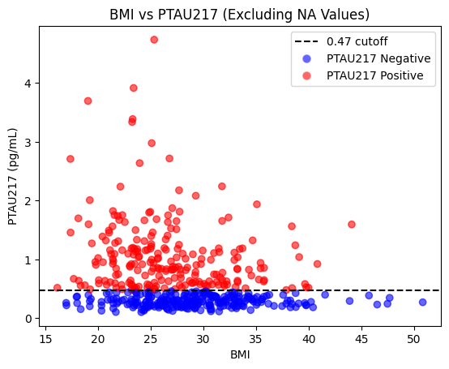

```python
# Ensure numeric and categorical columns are in the right dtype
valid_bmi = apoe_paper_df.loc[apoe_paper_df["bmi"].notna()].copy()

valid_bmi["bmi"] = pd.to_numeric(valid_bmi["bmi"], errors="coerce")
valid_bmi["ptau_217_avg_conc"] = pd.to_numeric(
    valid_bmi["ptau_217_avg_conc"], errors="coerce"
)
valid_bmi["ptau_bin"] = pd.to_numeric(valid_bmi["ptau_bin"], errors="coerce")

# Drop rows with missing or invalid numeric data
valid_bmi = valid_bmi.dropna(subset=["bmi", "ptau_217_avg_conc", "ptau_bin"])

# Plot
sc = plt.scatter(
    valid_bmi["bmi"],
    valid_bmi["ptau_217_avg_conc"],
    c=valid_bmi["ptau_bin"],
    cmap="bwr",
    vmin=0,
    vmax=1,
    alpha=0.6,
)

# Add cutoff line
plt.axhline(0.47, color="black", linestyle="--")

# Labels
plt.xlabel("BMI")
plt.ylabel("PTAU217 (pg/mL)")
plt.title("BMI vs PTAU217 (Excluding NA Values)")

# Legend
legend_elements = [
    Line2D([0], [0], color="black", linestyle="--", label="0.47 cutoff"),
    Line2D(
        [0],
        [0],
        marker="o",
        color="w",
        label="PTAU217 Negative",
        markerfacecolor="blue",
        markersize=8,
        alpha=0.6,
    ),
    Line2D(
        [0],
        [0],
        marker="o",
        color="w",
        label="PTAU217 Positive",
        markerfacecolor="red",
        markersize=8,
        alpha=0.6,
    ),
]

plt.legend(handles=legend_elements)
plt.show()
```

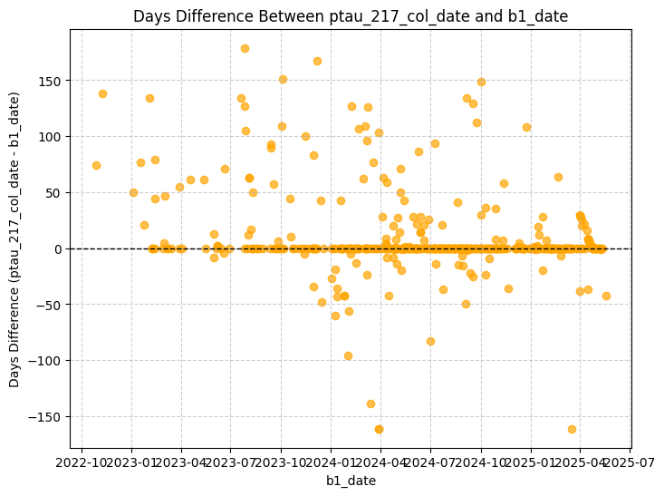

```python
# COPY OF THE WORKING DATAFRAME
df = apoe_paper_df.copy()

# Convert to datetime
df["ptau_217_col_date"] = pd.to_datetime(df["ptau_217_col_date"], errors="coerce")
df["b1_date"] = pd.to_datetime(df["b1_date"], errors="coerce")

# Compute days difference
df["days_diff_B1"] = (df["ptau_217_col_date"] - df["b1_date"]).dt.days

# Drop missing
df = df.dropna(subset=["ptau_217_col_date", "b1_date", "days_diff_B1"])

# Scatter plot
plt.figure(figsize=(8, 6))
plt.scatter(df["b1_date"], df["days_diff_B1"], alpha=0.7, color="orange")
plt.axhline(0, color="black", linestyle="--", linewidth=1)
plt.title("Days Difference Between ptau_217_col_date and b1_date")
plt.xlabel("b1_date")
plt.ylabel("Days Difference (ptau_217_col_date - b1_date)")
plt.grid(True, linestyle="--", alpha=0.6)
plt.show()
```

### checking date ranges

- summary of stats for each date column to collection date.

```python
# Copy for safety
df = apoe_paper_df.copy()

# Convert all relevant columns to datetime
date_cols = ["ptau_217_col_date", "b1_date"]
df[date_cols] = df[date_cols].apply(pd.to_datetime, errors="coerce")

# ------------------------------------------------------------
# Calculate days difference between collection and each form date
# NOTE:
#   Negative values  → pTau collection occurred BEFORE the visit form date
#   Positive values  → pTau collection occurred AFTER the visit form date
# ------------------------------------------------------------
diff_cols = {}
for form in [
    "b1",
]:
    col_name = f"diff_{form}"
    df[col_name] = (df["ptau_217_col_date"] - df[f"{form}_date"]).dt.days
    diff_cols[form] = col_name

# Drop rows missing all diffs
df = df.dropna(subset=list(diff_cols.values()), how="all")

# Compute summary statistics
summary = (
    df[list(diff_cols.values())]
    .agg(["mean", "median", "std", "min", "max"])
    .round(1)
    .rename(
        columns={
            "diff_b1": "b1",
        }
    )
)

# Center-align table output
table = tabulate(
    summary,  # type: ignore
    headers="keys",
    tablefmt="github",
    numalign="center",
    stralign="center",  # centers strings too
)

print("\nAverage day differences (ptau_217_col_date – Form Date):\n")
print(table)
print(
    """
NOTE:
- Negative values → pTau collection occurred BEFORE the visit form date (expected)
- Positive values → pTau collection occurred AFTER the visit form date (possible delay)
"""
)
```

```
Average day differences (ptau_217_col_date – Form Date):

|        |  b1  |
|--------|------|
|  mean  | 7.6  |
| median |  0   |
|  std   | 35.5 |
|  min   | -161 |
|  max   | 179  |

NOTE:
- Negative values → pTau collection occurred BEFORE the visit form date (expected)
- Positive values → pTau collection occurred AFTER the visit form date (possible delay)
```

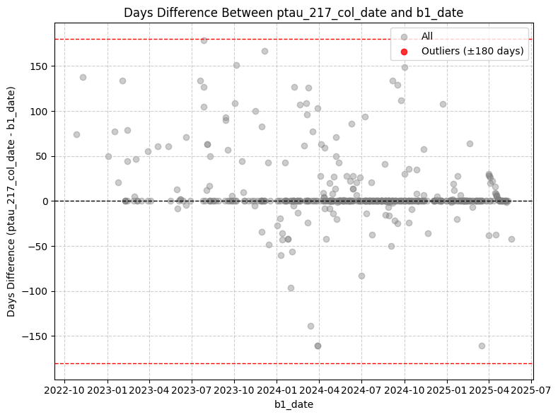

```python
# --- STEP 1: Make sure your date columns are datetime ---
df = apoe_paper_df.copy()
df["ptau_217_col_date"] = pd.to_datetime(df["ptau_217_col_date"], errors="coerce")
df["b1_date"] = pd.to_datetime(df["b1_date"], errors="coerce")

# --- STEP 2: Compute the days difference ---
df["days_diff_B1"] = (df["ptau_217_col_date"] - df["b1_date"]).dt.days

# --- STEP 3: Drop rows with missing dates ---
df = df.dropna(subset=["b1_date", "days_diff_B1"])

# --- STEP 4: Identify outliers (> ±180 days) ---
form_outliers = df[df["days_diff_B1"].abs() > 180]

# --- STEP 5: Plot ---
plt.figure(figsize=(8, 6))
plt.scatter(df["b1_date"], df["days_diff_B1"], alpha=0.4, color="gray", label="All")
plt.scatter(
    form_outliers["b1_date"],
    form_outliers["days_diff_B1"],
    alpha=0.8,
    color="red",
    label="Outliers (±180 days)",
)

plt.axhline(180, color="red", linestyle="--", linewidth=1)
plt.axhline(-180, color="red", linestyle="--", linewidth=1)
plt.axhline(0, color="black", linestyle="--", linewidth=1)

plt.title("Days Difference Between ptau_217_col_date and b1_date")
plt.xlabel("b1_date")
plt.ylabel("Days Difference (ptau_217_col_date - b1_date)")
plt.legend()
plt.grid(True, linestyle="--", alpha=0.6)
plt.tight_layout()
plt.show()
```

## Summary of Statistical Analyses

```python
# Copy for safety
df = apoe_paper_df.copy()

# Convert continuous vars to numeric
df["age"] = pd.to_numeric(df["age"], errors="coerce")
df["educ"] = pd.to_numeric(df["educ"], errors="coerce")

# Convert categorical vars to numeric
for col in ["sex", "normcog", "mci", "demented", "hypert", "diabet", "hypchol"]:
    df[col] = pd.to_numeric(df[col], errors="coerce")

# Create binary female variable (2 = Female, 1 = Male)
df["female"] = (df["sex"] == 2).astype(int)

continuous_vars = [
    "age",
    "educ",
]

categorical_vars = [
    "female",
    "normcog",
    "mci",
    "demented",
    "hypert",
    "diabet",
    "hypchol",
]


def summarize_cont(series):
    return f"{series.mean():.1f} ({series.std():.1f})"


def summarize_cat(series):
    count = int(series.sum())
    pct = 100 * count / len(series)
    return f"{count} ({pct:.1f})"


groups = {
    "Total Cohort": df,
    "Hispanic": df[df["hispanic"] == "1"],
    "NHW": df[df["hispanic"] == "0"],
}

group_labels = {name: f"{name} (N = {len(subdf)})" for name, subdf in groups.items()}

pretty_names = {
    "age": "Age, Mean (SD)",
    "educ": "Years of education, Mean (SD)",
    "female": "Female, N (%)",
    "normcog": "Normal Cognition, N (%)",
    "mci": "Mild Cognitive Impairment, N (%)",
    "demented": "Dementia, N (%)",
    "hypert": "Hypertension, N (%)",
    "diabet": "Type II Diabetes, N (%)",
    "hypchol": "Hypercholesterolemia, N (%)",
}

rows = []

for var in continuous_vars + categorical_vars:
    row = {"Characteristic": pretty_names[var]}
    for group_name, subdf in groups.items():
        s = subdf[var]
        if var in continuous_vars:
            value = summarize_cont(s)
        else:
            value = summarize_cat(s)
        row[group_labels[group_name]] = value
    rows.append(row)

descriptives_table = pd.DataFrame(rows).reset_index(drop=True)
styled = (
    descriptives_table.style.hide(axis="index")
    # Left-align + bold the Characteristic column
    .set_properties(
        subset=["Characteristic"], **{"text-align": "left", "font-weight": "bold"}
    )
    # Center ALL other columns (headers + cells)
    .set_properties(
        subset=[col for col in descriptives_table.columns if col != "Characteristic"],
        **{"text-align": "center"},
    )
    # Center ALL column headers
    .set_table_styles(
        [{"selector": "th.col_heading", "props": [("text-align", "center")]}]
    )
)

styled
```

| Characteristic | Total Cohort (N = 488) | Hispanic (N = 264) | NHW (N = 224) |
| --- | --- | --- | --- |
| Age, Mean (SD) | 72.2 (9.4) | 71.3 (9.2) | 73.4 (9.5) |
| Years of education, Mean (SD) | 15.4 (6.3) | 14.2 (6.3) | 16.8 (6.0) |
| Female, N (%) | 296 (60.7) | 179 (67.8) | 117 (52.2) |
| Normal Cognition, N (%) | 257 (52.7) | 157 (59.5) | 100 (44.6) |
| Mild Cognitive Impairment, N (%) | 108 (22.1) | 65 (24.6) | 43 (19.2) |
| Dementia, N (%) | 118 (24.2) | 39 (14.8) | 79 (35.3) |
| Hypertension, N (%) | 287 (58.8) | 170 (64.4) | 117 (52.2) |
| Type II Diabetes, N (%) | 234 (48.0) | 159 (60.2) | 75 (33.5) |
| Hypercholesterolemia, N (%) | 328 (67.2) | 189 (71.6) | 139 (62.1) |

```python
"""
Comparing the proportion of females between Hispanic and NHW within
each diagnosis category (Normal, MCI, Dementia)
to see whether female representation differed by ethnicity.
"""

# Copy for safety
df = apoe_paper_df.copy()

# Convert categorical vars to numeric
for col in ["sex", "normcog", "mci", "demented"]:
    df[col] = pd.to_numeric(df[col], errors="coerce")

df["female"] = (df["sex"] == 2).astype(int)

# Mapping labels
diagnosis_labels = {
    "normcog": "Normal Cognition, N (%)",
    "mci": "Mild Cognitive Impairment, N (%)",
    "demented": "Dementia, N (%)",
}


# dx's
def get_dx(row):
    if row["demented"] == 1:
        return "Dementia"
    elif row["mci"] == 1:
        return "Mild Cognitive Impairment"
    elif row["normcog"] == 1:
        return "Normal Cognition"
    else:
        return None


df["dx"] = df.apply(get_dx, axis=1)  # type: ignore

total_female = df["female"].sum()
female_hisp = df[df["hispanic"] == "1"]["female"].sum()
female_nhw = df[df["hispanic"] == "0"]["female"].sum()

rows = []

ordered_dx = [
    ("normcog", "Normal Cognition"),
    ("mci", "Mild Cognitive Impairment"),
    ("demented", "Dementia"),
]

for dx_var, dx_name in ordered_dx:

    # --- female counts per diagnosis (overall) ---
    females_with_dx = df[(df[dx_var] == 1) & (df["female"] == 1)]
    female_dx_n = len(females_with_dx)
    female_dx_pct = round(100 * female_dx_n / total_female, 1)

    # --- Hispanic vs NHW subsets ---
    hisp_dx = df[(df[dx_var] == 1) & (df["hispanic"] == "1")]
    nhw_dx = df[(df[dx_var] == 1) & (df["hispanic"] == "0")]

    hisp_n = len(hisp_dx)
    nhw_n = len(nhw_dx)

    # raw female counts
    hisp_f = hisp_dx["female"].sum()
    nhw_f = nhw_dx["female"].sum()

    # percentages
    hisp_pct = round(100 * hisp_f / hisp_n, 1) if hisp_n else None
    nhw_pct = round(100 * nhw_f / nhw_n, 1) if nhw_n else None

    # p-value
    if hisp_n > 0 and nhw_n > 0:
        _, pval = proportions_ztest([hisp_f, nhw_f], [hisp_n, nhw_n])
    else:
        pval = None

    rows.append(
        {
            "Diagnosis": diagnosis_labels[dx_var],
            f"Female Cohort (n= {total_female})": f"{female_dx_n} ({female_dx_pct}%)",
            f"Female Hispanic (n= {female_hisp})": f"{hisp_f} ({hisp_pct}%)",
            f"Female NHW  (n= {female_nhw})": f"{nhw_f} ({nhw_pct}%)",
            "p-value": pval,
        }
    )

final_table = pd.DataFrame(rows)
styled = (
    final_table.style.hide(axis="index")
    # Left-align + bold the Diagnosis column
    .set_properties(
        subset=["Diagnosis"], **{"text-align": "left", "font-weight": "bold"}
    )
    # Center ALL other columns
    .set_properties(
        subset=[col for col in final_table.columns if col != "Diagnosis"],
        **{"text-align": "center"},
    )
    # Center ALL column headers
    .set_table_styles(
        [{"selector": "th.col_heading", "props": [("text-align", "center")]}]
    )
)

styled
```

| Diagnosis | Female Cohort (n= 296) | Female Hispanic (n= 179) | Female NHW (n= 117) | p-value |
| --- | --- | --- | --- | --- |
| Normal Cognition, N (%) | 179 (60.5%) | 115 (73.2%) | 64 (64.0%) | 0.115903 |
| Mild Cognitive Impairment, N (%) | 66 (22.3%) | 45 (69.2%) | 21 (48.8%) | 0.033326 |
| Dementia, N (%) | 48 (16.2%) | 16 (41.0%) | 32 (40.5%) | 0.956920 |

```python
"""
Tested whether the overall sex distribution (male vs female)
differed across diagnosis groups
separately within Hispanic and NHW using chi-square tests,
assessing whether sex imbalance across diagnoses varies by ethnicity.
"""

# Copy for safety
df = apoe_paper_df.copy()

# Convert categorical vars to numeric
for col in ["sex", "normcog", "mci", "demented"]:
    df[col] = pd.to_numeric(df[col], errors="coerce")

df["female"] = (df["sex"] == 2).astype(int)


# dx mapping
def get_dx(row):
    if row["demented"] == 1:
        return "Dementia"
    if row["mci"] == 1:
        return "Mild Cognitive Impairment"
    if row["normcog"] == 1:
        return "Normal Cognition"
    return None


df["dx"] = df.apply(get_dx, axis=1)  # type: ignore
df = df.dropna(subset=["dx"])

# sex labels
df["sex_label"] = df["sex"].map({1: "Male", 2: "Female"})

# enthnicity tables
cont_h = pd.crosstab(
    df[df["hispanic"] == "1"]["sex_label"], df[df["hispanic"] == "1"]["dx"]
)

cont_n = pd.crosstab(
    df[df["hispanic"] == "0"]["sex_label"], df[df["hispanic"] == "0"]["dx"]
)

chi2_h, p_h, _, _ = chi2_contingency(cont_h)
chi2_n, p_n, _, _ = chi2_contingency(cont_n)


def format_table(tab):
    tab2 = tab.reset_index().rename(columns={tab.index.name: "Group"})

    tbl = (
        tab2.style.hide(axis="index")
        # Bold + left-align the row label column
        .set_properties(
            subset=["Group"], **{"text-align": "left", "font-weight": "bold"}
        )
        # Center all data columns
        .set_properties(
            subset=[col for col in tab2.columns if col != "Group"],
            **{"text-align": "center"}
        )
        # Center headers
        .set_table_styles(
            [{"selector": "th.col_heading", "props": [("text-align", "center")]}]
        )
    )
    return tbl


hispanic_table_output = format_table(cont_h)
nhw_table_output = format_table(cont_n)

print("\nHispanic Sex x Diagnosis Table:")
display(hispanic_table_output)

print("\nNHW Sex x Diagnosis Table:")
display(nhw_table_output)


summary_df = pd.DataFrame(
    {"Ethnicity": ["Hispanic", "NHW"], "Chi-square p-value": [p_h, p_n]}
)

summary_output = (
    summary_df.style.hide(axis="index")
    .set_properties(
        subset=["Ethnicity"], **{"text-align": "left", "font-weight": "bold"}
    )
    .set_properties(subset=["Chi-square p-value"], **{"text-align": "center"})
    .set_table_styles(
        [{"selector": "th.col_heading", "props": [("text-align", "center")]}]
    )
)

print("\nSummary of Sex x Diagnosis Tests:")
display(summary_output)
```

```
Hispanic Sex x Diagnosis Table:
```

| Group | Dementia | Mild Cognitive Impairment | Normal Cognition |
| --- | --- | --- | --- |
| Female | 16 | 45 | 115 |
| Male | 23 | 20 | 42 |

```
NHW Sex x Diagnosis Table:
```

| Group | Dementia | Mild Cognitive Impairment | Normal Cognition |
| --- | --- | --- | --- |
| Female | 32 | 21 | 64 |
| Male | 47 | 22 | 36 |

```
Summary of Sex x Diagnosis Tests:
```

| Ethnicity | Chi-square p-value |
| --- | --- |
| Hispanic | 0.000582 |
| NHW | 0.006434 |

**← Back to Project Index**